# Colombia: concentración espacial de pérdida de servicios ecosistémicos y exposición de beneficiarios

Aplicación de la metodología global WWF/NatCap de análisis de hotspots de cambio en la provisión de servicios ecosistémicos al caso colombiano

20 August 2026

WWF — Global Science

Preparado por Jerónimo Rodríguez Escobar Global Science, WWF 20 August 2026

Este análisis identifica, para Colombia, cuáles áreas concentran mayor valor para las contribuciones de la naturaleza a las personas (activos naturales críticos), dónde se concentra el cambio más severo (1992–2020) en la provisión de cinco servicios ecosistémicos, y dónde ambas cosas coinciden — la señal más útil para priorizar decisiones de planificación territorial.

| **Activos naturales críticos** | Área requerida para sostener el 90%+ de las contribuciones de la naturaleza a las personas (Chaplin-Kramer et al. 2022) |
| --- | --- |
| **Servicios evaluados** | Polinización, Exportación de sedimentos, Exportación de nitrógeno, Acceso a la naturaleza, Riesgo costero |

A continuación, los hallazgos principales; la metodología completa (cómo se define un hotspot de cambio, y por qué) sigue después.

## Hallazgos clave

**Prioridad.** El 57,9% de los hotspots de cambio en la provisión de servicios ecosistémicos identificados en Colombia coincide con un activo natural crítico — lugares que proveen simultáneamente las mayores contribuciones de la naturaleza a las personas *y* donde ese cambio es más severo. Este traslape es una señal directa para priorizar dónde evitar o mitigar impacto — no solo de infraestructura vial: la misma lógica aplica a proyectos agrícolas, forestales, mineros, energéticos e industriales en general.

**Dónde.** De los cinco servicios evaluados, Colombia concentra, de forma desproporcionada, los **hotspots globales de cambio** de dos de ellos — **Polinización (1,60%)** y **Exportación de sedimentos (1,32%)** respecto al 0,87% de la superficie terreestre que cubre.

**Quién.** El área de influencia combinada de estos hotspots de cambio (definids como 50km aguas abajo o hasta 1 hora de tiempo de viaje) alcanza al **75,8% de la población colombiana — 38,1 millones de personas**. El nivel más estricto (4 o más de los 5 servicios con cambio extremo simultáneo) alcanza al 35,5% (17,9 millones).

**Oportunidad: infraestructura vial.** La exportación de sedimentos —uno de los dos servicios con mayor concentración de hotspots de cambio en Colombia— está directamente ligada a erosión y escorrentía inducidas por construcción vial. La oportunidad: usar esta misma capa para evaluar, antes de construir, el riesgo de erosión/sedimentación de corredores viales propuestos — no solo observar el patrón después del hecho. Encaja en la etapa más temprana de los Lineamientos de Infraestructura Verde Vial (LIVV): una señal de riesgo estandarizada y repetible para la selección de corredores.

## Enfoque

> Identificar, para Colombia: cuáles áreas son más valiosas para sostener las contribuciones de la naturaleza a las personas; dónde se concentra el cambio más severo en la provisión de servicios ecosistémicos (1992–2020); dónde ambas cosas coinciden; y quién queda expuesto — como base para priorizar decisiones de planificación territorial, viales o de otro tipo.

[output not shown]

## Activos naturales críticos

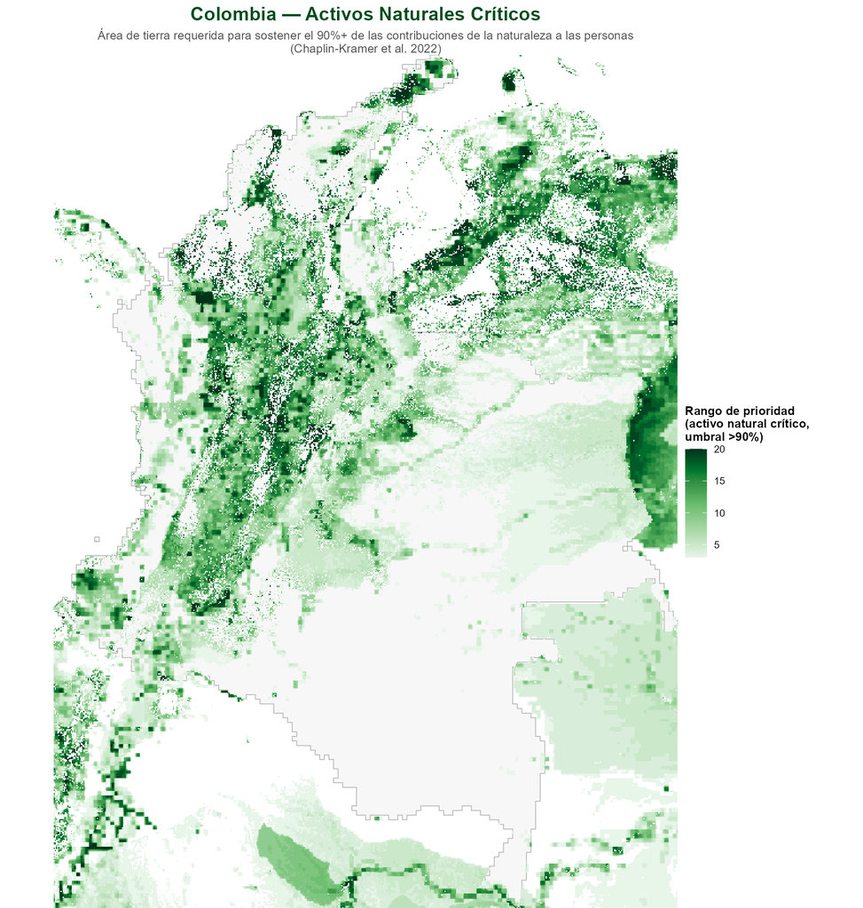

Área requerida para sostener el 90%+ de las contribuciones de la naturaleza a las personas (Chaplin-Kramer et al. 2022, optimización nacional sobre 12 NCP locales)

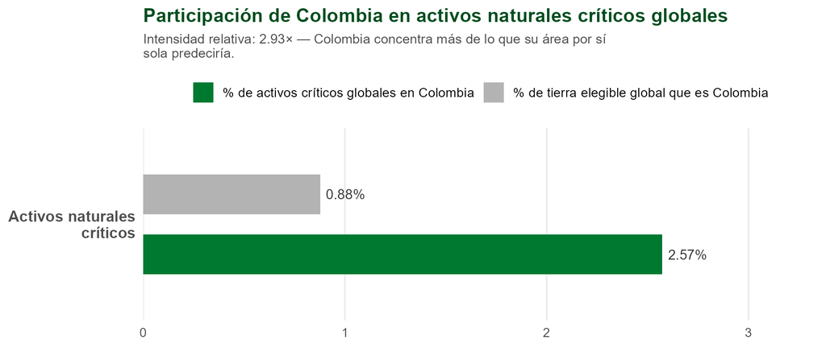

Participación de Colombia en los activos naturales críticos globales frente a su participación en la tierra elegible global (según la máscara de tierra propia del ráster de Chaplin-Kramer et al. 2022).

**Colombia concentra 2,57% de los activos naturales críticos del mundo, siendo apenas 0,88% de la tierra elegible global — una intensidad relativa de 2,93×**, más alta que cualquiera de los hallazgos de hotspots de cambio.

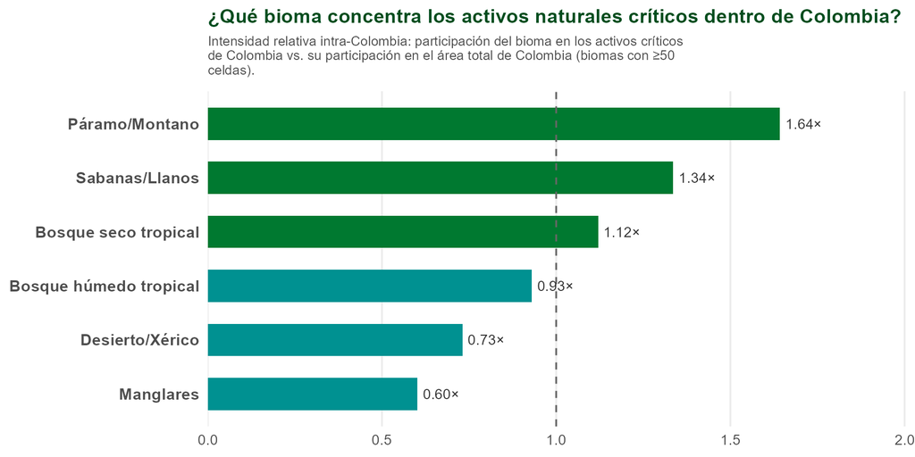

Intensidad relativa intra-Colombia: participación del bioma en los activos críticos de Colombia frente a su participación en el área total del país.

Dentro de Colombia, **páramo/montano** concentra la mayor proporción de activos críticos (1,64×), seguido de **sabanas/Llanos** (1,34×) — consistente con el rol de los páramos como reguladores hídricos (páramos que abastecen a Bogotá, entre otros).

## Dónde: concentración de hotspots de cambio

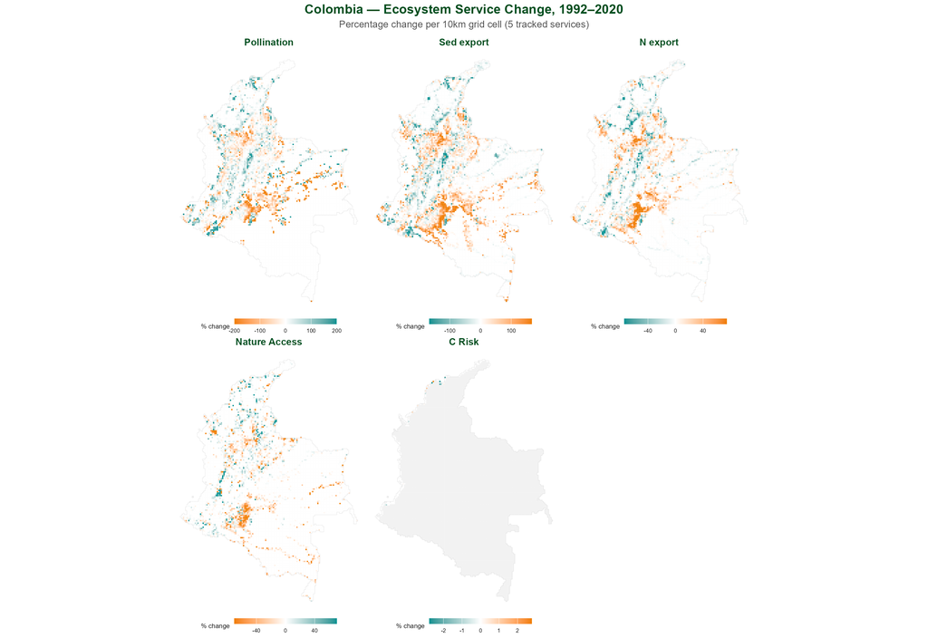

Cambio porcentual por celda de 10km, 1992–2020, para los 5 servicios evaluados — insumo crudo sobre el que se calculan los hotspots de cambio.

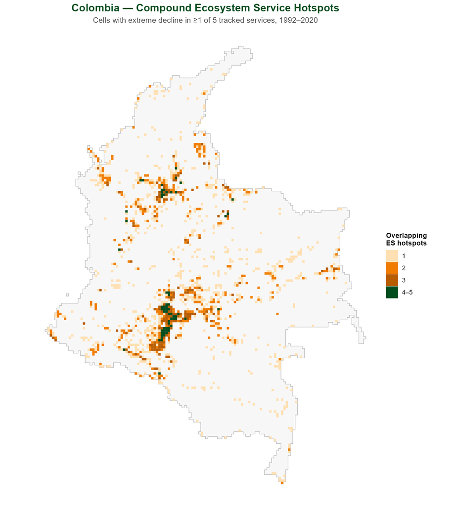

Celdas identificadas como hotspot de cambio (percentil 5% de cambio más severo) en 1 o más de los 5 servicios evaluados. La concentración más fuerte está en tres departamentos, casi empatados y muy por encima del resto: Meta, Caquetá y Antioquia.

## Prioridad: dónde coinciden valor y cambio

La coincidencia entre ambas capas —un lugar valioso *y* con cambio severo permite refinar la priorización:

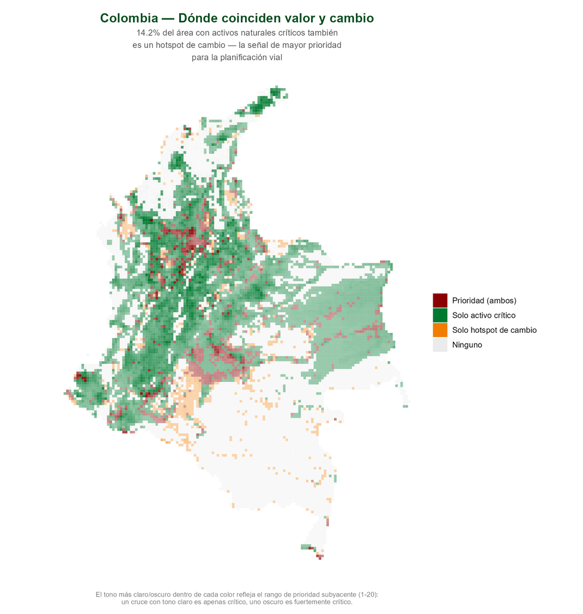

Cuatro clases: celdas priorizadas, solo activo crítico, solo hotspot de cambio, ninguno. La Prioridad más fuerte está en Meta, Caquetá y Antioquia — los mismos departamentos que ya aparecían en el mapa de hotspots.

| Métrica | Valor |
| --- | --- |
| Celdas de activo natural crítico | 5.797 (51,0% de Colombia) |
| Celdas de hotspot de cambio | 1.423 (12,5% de Colombia) |
| Celdas que son ambas cosas (“Prioridad”) | 824 (7,2% de Colombia) |
| **% de hotspots de cambio que también son activo crítico** | **57,9%** |
| % de activos críticos que también son hotspot de cambio | 14,2% |

**Casi 6 de cada 10 hotspots de cambio en Colombia ocurren en un lugar que también es un activo natural crítico.**

## Zoom in: ¿qué bioma concentra el cambio dentro de Colombia?

**Dentro de Colombia**, ¿qué bioma concentra desproporcionadamente los hotspots de cambio del propio país?

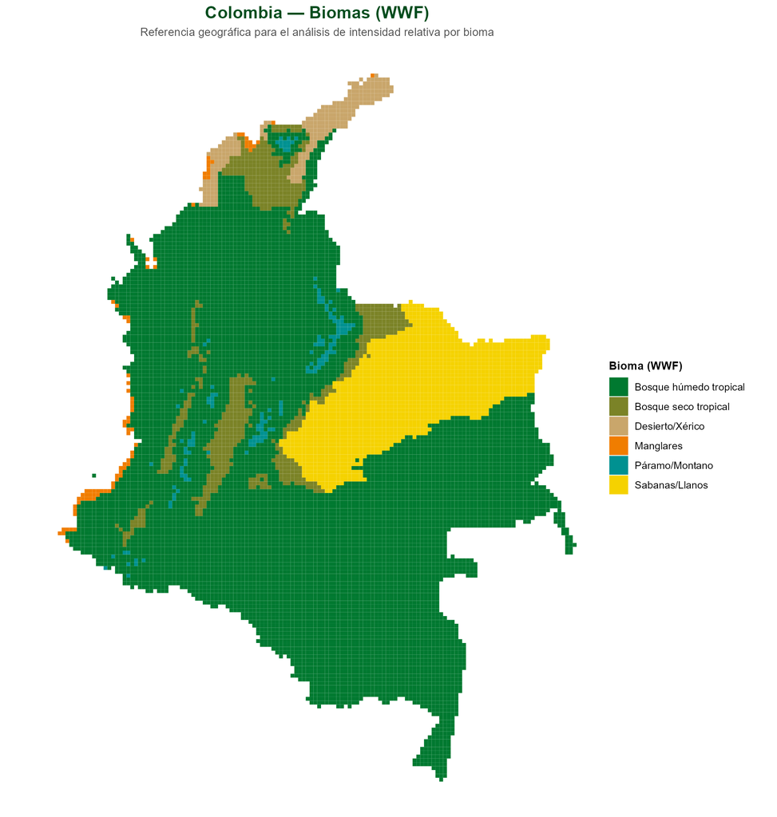

Biomas de Colombia (clasificación WWF).

Servicios destacados Otros servicios

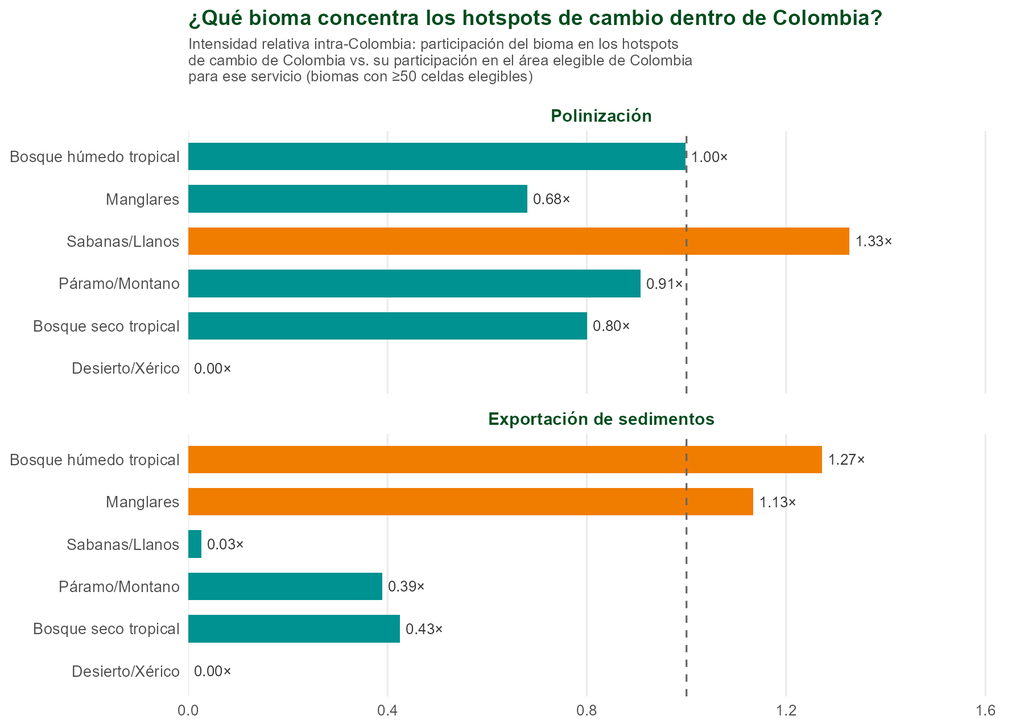

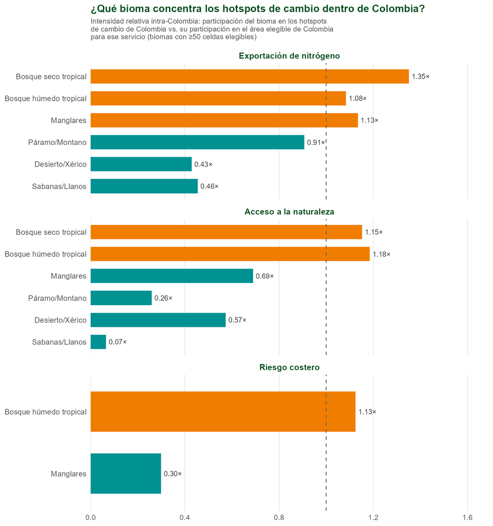

- **Exportación de sedimentos** concentra su cambio en el **bosque húmedo tropical** (1,27×) y, en menor medida, los **manglares** (1,13×) — coherente con procesos de erosión y sedimentación en cuencas boscosas y zonas costeras.
- **Polinización** muestra su mayor concentración en **sabanas/Llanos** (1,33×), no en el bosque húmedo tropical (esencialmente proporcional, 1,00×) — un patrón distinto, consistente con presión sobre paisajes agrícolas y de pastizal en la frontera de la Orinoquía, no solo sobre bosque.
- Ambos hallazgos usan la misma corrección metodológica que el resto del reporte: el denominador es el área elegible de cada servicio dentro de Colombia, no el área total del bioma.

## Análisis estadístico

Servicios destacados Otros servicios

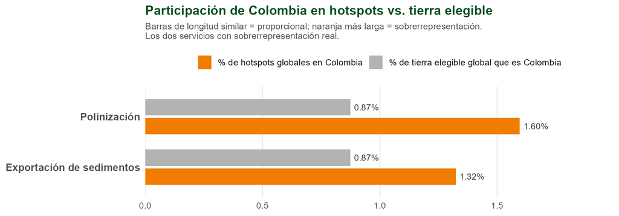

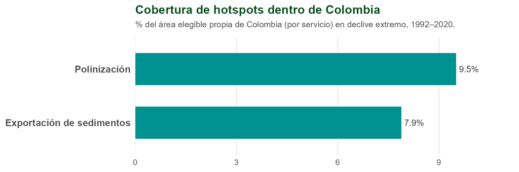

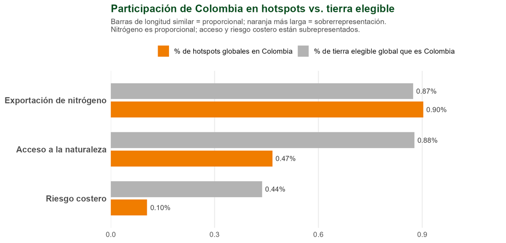

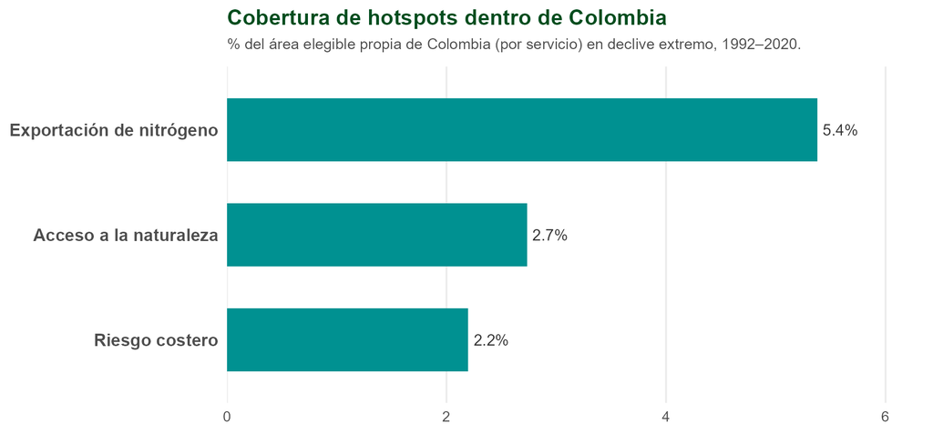

## Quién: alcance de beneficiarios

Zona de alcance Densidad de población

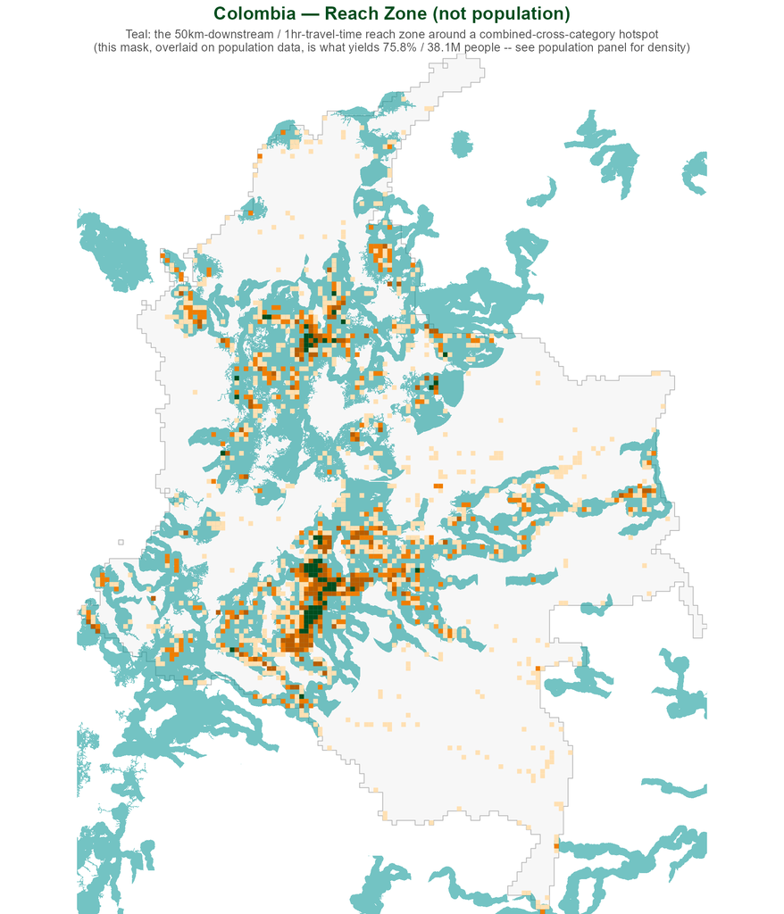

Área en turquesa: la zona de alcance —50km aguas abajo o 1 hora de tiempo de viaje de un hotspot de cambio de categoría cruzada combinada (al menos un hotspot de cambio en la vía del agua *y* al menos uno en la vía de acceso)— no la población en sí. La cifra de población (75,8%, 38,1 millones de personas) se calcula superponiendo esta máscara geográfica sobre datos de población.

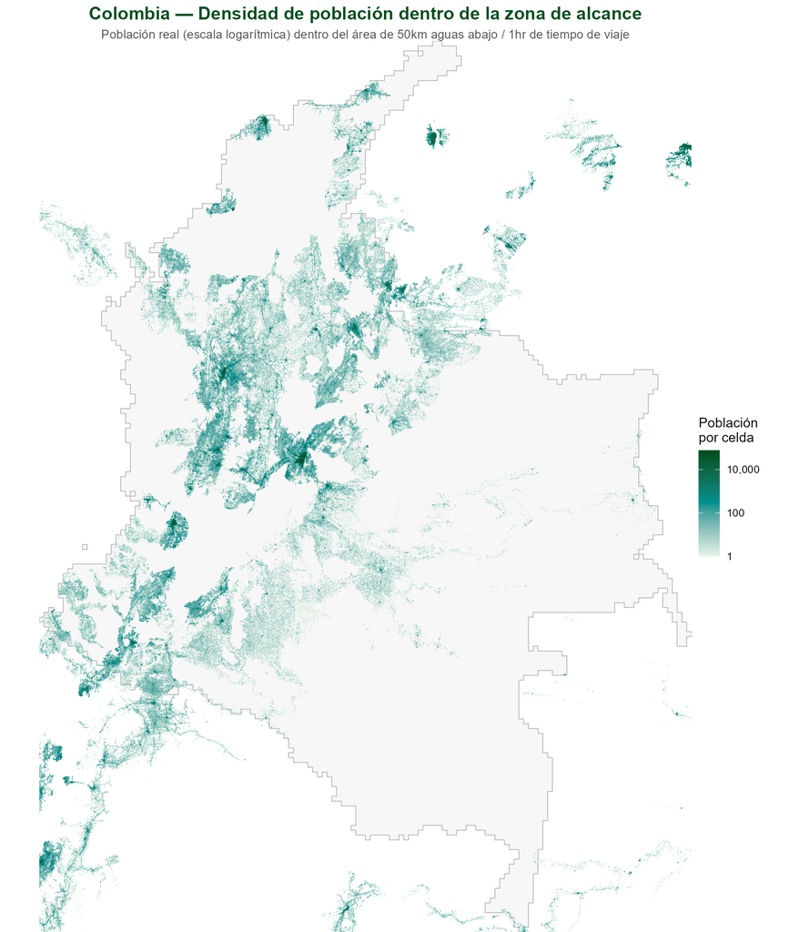

Población real (escala logarítmica) dentro de la zona de alcance — esta es la capa que sí muestra dónde está la gente, no solo dónde está la máscara geográfica.

| Categoría | % de población alcanzada | Personas |
| --- | --- | --- |
| Categoría cruzada combinada | 75,8% | 38,1 millones |
| Nivel 4+ (4 o más de 5 servicios) | 35,5% | 17,9 millones |

Los parámetros de alcance (50km aguas abajo, 1 hora de tiempo de viaje por red vial) son los mismos del análisis global.

## Propuesta

Es posible producir un corte Colombia-nacional del análisis de prioridad (activos críticos ∩ hotspots de cambio) a mayor detalle —Llanos/Orinoquía, zona de transición amazónica, páramos— con la misma metodología estandarizada mostrada aquí, y leído a través de una perspectiva de dinámicas de frontera agrícola con base en investigación de campo propia en la Orinoquía colombiana.

## Alcance y advertencias

[output not shown]

Datos: `data/processed/tables/regional_subsets/nev_name/hotspot_area_stats_Colombia.csv`, `data/processed/tables/colombia_beneficiary_population.csv`, `data/processed/tables/colombia_biome_area_stats.csv`, `data/processed/tables/colombia_priority_overlap_summary.csv` · Activos naturales críticos: Chaplin-Kramer et al. (2022), *Nature Ecology & Evolution*, doi.org/10.1038/s41559-022-01934-5 · Mapas: `outputs/plots/colombia_report/` · Metodología completa: `docs/methodology.md`